# Modeling Relationships Between Variables

From Correlation Coefficients to Regression Lines and Interpretation

Bogdan G. Popescu

bogdan.popescu@johncabot.edu

John Cabot University

## Table of Contents

1. Correlation
2. Simple Linear Regression
3. Regression Output & Interpretation

## Intro

A **correlation coefficient** is a statistic that measures the strength of the relationship between two variables.

For example, urbanization could be positively correlated with life expectancy.

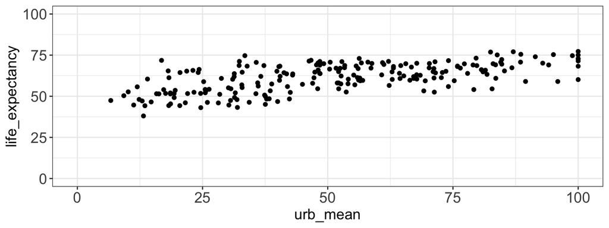

```r
library(dplyr)
library(ggplot2)
setwd("/Users/bgpopescu/Library/CloudStorage/Dropbox/john_cabot/teaching/research_workshop/lecture9/")

life_expectancy_df <- read.csv(file = './data/life-expectancy.csv')
urbanization_df <- read.csv(file = './data/share-of-population-urban.csv')

urbanization_df2<-urbanization_df%>%
  dplyr::group_by(Entity, Code)%>%
  dplyr::summarize(urb_mean=mean(Urban.population....of.total.population.))

life_expectancy_df2<-life_expectancy_df%>%
  dplyr::group_by(Entity, Code)%>%
  dplyr::summarize(life_expectancy=mean(Life.expectancy.at.birth..historical.))

weird_labels <- c("OWID_KOS", "OWID_WRL", "")
clean_life_expectancy_df<-subset(life_expectancy_df2, !(Code %in% weird_labels))

weird_labels <- c("OWID_KOS", "OWID_WRL", "")
clean_urbanization_df<-subset(urbanization_df2, !(Code %in% weird_labels))

clean_urbanization_df<-subset(clean_urbanization_df, select = -c(Entity))
merged_data<-left_join(clean_life_expectancy_df, clean_urbanization_df, by = c("Code"="Code"))
merged_data2<-na.omit(merged_data)

figure1<-ggplot(merged_data, aes(x=urb_mean, y=life_expectancy)) +
  geom_point() +
  theme_bw()+
  theme(axis.text.x = element_text(size=14),
        axis.text.y = element_text(size=14),
        axis.title=element_text(size=14),
        plot.title = element_text(hjust = 0.5))+
  xlim(0, 100) +
  ylim(0, 100)
figure1
```

## Intro

It turns out that the correlation between urbanization and life expectancy is: 0.63

```r
library(dplyr)
setwd("/Users/bgpopescu/Library/CloudStorage/Dropbox/john_cabot/teaching/research_workshop/lecture9/")

life_expectancy_df <- read.csv(file = './data/life-expectancy.csv')
urbanization_df <- read.csv(file = './data/share-of-population-urban.csv')

urbanization_df2<-urbanization_df%>%
  dplyr::group_by(Entity, Code)%>%
  dplyr::summarize(urb_mean=mean(Urban.population....of.total.population.))

life_expectancy_df2<-life_expectancy_df%>%
  dplyr::group_by(Entity, Code)%>%
  dplyr::summarize(life_expectancy=mean(Life.expectancy.at.birth..historical.))

weird_labels <- c("OWID_KOS", "OWID_WRL", "")
clean_life_expectancy_df<-subset(life_expectancy_df2, !(Code %in% weird_labels))

weird_labels <- c("OWID_KOS", "OWID_WRL", "")
clean_urbanization_df<-subset(urbanization_df2, !(Code %in% weird_labels))

clean_urbanization_df<-subset(clean_urbanization_df, select = -c(Entity))
merged_data<-left_join(clean_life_expectancy_df, clean_urbanization_df, by = c("Code"="Code"))
merged_data2<-na.omit(merged_data)
```

```r
cor(merged_data$life_expectancy, merged_data$urb_mean, use = "complete.obs")
```

```
[1] 0.630194
```

This the the formal definition for a correlation:

$$r = \frac{\frac{\sum (x_i - \bar{x})(y_i - \bar{y})}{n-1}}{s_x \cdot s_y}$$

- The Pearson’s correlation coefficient *r* describes the strength and nature of the relationship between two variables.

## The Correlation Coefficient

$$r = \frac{\frac{\sum (x_i - \bar{x})(y_i - \bar{y})}{n-1}}{s_x \cdot s_y}$$

- $r$ is the **sample Pearson correlation coefficient**
- $x_i$ and $y_i$ are the values of variables X and Y for the **same observation**
- $\bar{x}$ and $\bar{y}$ are the **sample means** of variables X and Y
- $n$ is the **sample size**
- $s_x$ and $s_y$ are the **sample standard deviations** of X and Y

## Correlation vs. Causation

A correlation signifies the relationship between two variables.

It is tempting to argue that changes in one variable cause changes in the other.

This is problematic for three reasons:

- We do not know the **direction of causation**: does X produce changes in y, or does y produce changes in x?
- There might be a **third variable z**, which causes changes in both x and y.
- Both x and y could be **measured with error**.

## Correlation vs. Causation

All of these problems suggest that there is **endogeneity** in the relationship between X and Y.

**The lesson:** Correlation does **not** imply causation.

## Regression Line

- We will make predictions with the help of *regressions*.
- These can be written as:

$$\hat{y}_i = b x_i + a$$

Where:

- $\hat{y}_i$ – individual predicted value on the dependent variable
- $x_i$ – individual value of the independent variable

## Regression Line

- We will make predictions with the help of *regressions*.
- These can be written as:

$$\hat{y}_i = b x_i + a$$

This is very similar to the formula $y = mx + b$, which represents a linear equation in mathematics:

- $m$ – slope
- $b$ – y-intercept

## Regression Line

### Regression Example

In the urbanization and life expectancy example, we know:

- $\bar{x} = \overline{\text{urbanization}} = 51.33$
- $\bar{y} = \overline{\text{life_expectancy}} = 61.259$
- $s_x = \text{standard deviation} = \sqrt{\frac{\sum (x_i - \bar{x})^2}{n}} = 24.18021$
- $s_y = \text{standard deviation} = \sqrt{\frac{\sum (y_i - \bar{y})^2}{n}} = 8.643744$
- $r = \frac{\frac{\sum (x_i - \bar{x})(y_i - \bar{y})}{n}}{s_x \cdot s_y} = 0.6303347$

## Regression Line

### Calculating the Slope

We can plug in these numbers into the formula and obtain the following:

$$b = r \cdot \frac{s_y}{s_x}$$

$$b = 0.6303347 \cdot \frac{8.643744}{24.18021}$$

$$b = 0.6303347 \cdot 0.3574718$$

$$b = 0.2253269$$

## Regression Line

### Calculating the Slope

We can obtain the 0.2252918 in the following way:

```r
x<-lm(life_expectancy~urb_mean, data=merged_data2)
summary(x)
```

```
Call:
lm(formula = life_expectancy ~ urb_mean, data = merged_data2)

Residuals:
     Min       1Q   Median       3Q      Max
-14.6442  -4.2065  -0.5017   5.0702  18.3283

Coefficients:
            Estimate Std. Error t value Pr(>|t|)
(Intercept) 49.69757    1.08225   45.92   <2e-16 ***
urb_mean     0.22529    0.01906   11.82   <2e-16 ***
---
Signif. codes:  0 '***' 0.001 '**' 0.01 '*' 0.05 '.' 0.1 ' ' 1

Residual standard error: 6.742 on 212 degrees of freedom
Multiple R-squared:  0.3971,    Adjusted R-squared:  0.3943
F-statistic: 139.7 on 1 and 212 DF,  p-value: < 2.2e-16
```

## Regression Line

### Calculating the Slope

This is what the slope looks like.

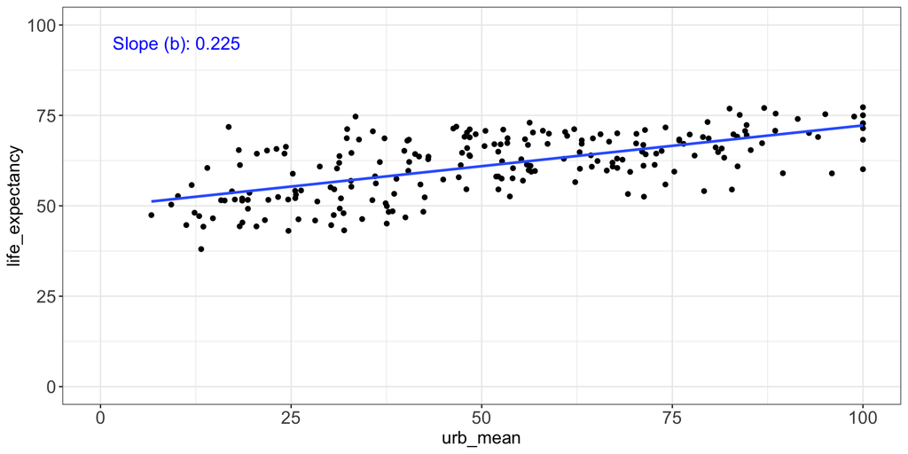

```r
# Fit model
x <- lm(life_expectancy ~ urb_mean, data = merged_data2)
coef_val <- round(coef(x)["urb_mean"], 3)

# Create label
coef_label <- paste("Slope (b):", coef_val)

# Create plot
figure1 <- ggplot(merged_data, aes(x = urb_mean, y = life_expectancy)) +
  geom_point() +
 geom_smooth(method = "lm", se = FALSE) +
  theme_bw() +
  theme(
    axis.text.x = element_text(size = 14),
    axis.text.y = element_text(size = 14),
    axis.title = element_text(size = 14),
    plot.title = element_text(hjust = 0.5)
  ) +
  xlim(0, 100) +
  ylim(0, 100) +
  annotate("text", x = 10, y = 95, label = coef_label, size = 5, color = "blue")

figure1
```

## Regression Line

### Calculating the Slope

What if the slope was negative?

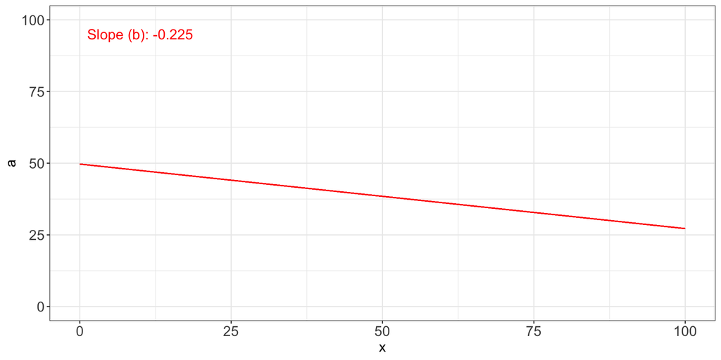

```r
# Simulate negative relationship
coef_val <- -round(coef(x)["urb_mean"], 3)

# Create label
coef_label <- paste("Slope (b):", coef_val)
a <-round(coef(x)["(Intercept)"], 3)

# Plot
figure1x <- ggplot(merged_data2, aes(x = urb_mean, y = life_expectancy)) +
#  geom_point() +
  geom_segment(aes(x = 0, y = a, xend = 100, yend = coef_val * max(merged_data2$urb_mean) + a), color = "red")+

  #geom_smooth(method = "lm", se = FALSE, color = "red") +
  theme_bw() +
  theme(
    axis.text.x = element_text(size = 14),
    axis.text.y = element_text(size = 14),
    axis.title = element_text(size = 14),
    plot.title = element_text(hjust = 0.5)
  ) +
  xlim(0, 100) +
  ylim(0, 100) +
  annotate("text", x = 10, y = 95, label = coef_label, size = 5, color = "red")

figure1x
```

## Regression Line

### Regression Example

The next step is to calculate $a$ using the formula:

$$\begin{align*}
a &= \bar{y} - b \bar{x} \\
a &= 61.259 - 0.2253269 \cdot 51.33 \\
a &= 61.259 - 11.56603 \\
a &= 49.69297
\end{align*}$$

## Regression Line

### Regression Example

This is the $a$.

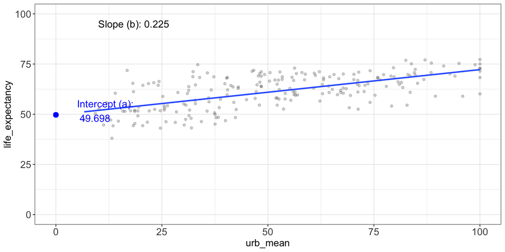

```r
# Fit model
x <- lm(life_expectancy ~ urb_mean, data = merged_data2)

# Extract slope (b) and intercept (a)
slope_val      <- round(coef(x)["urb_mean"], 3)
intercept_val  <- round(coef(x)["(Intercept)"], 3)

# Labels
slope_label     <- paste("Slope (b):", slope_val)
intercept_label <- paste("Intercept (a):\n", intercept_val)

# Build plot
figure1 <- ggplot(merged_data2, aes(x = urb_mean, y = life_expectancy)) +
  geom_point(color = "black", alpha = 0.2) +
  geom_smooth(method = "lm", se = FALSE, alpha = 0.2) +  # color via aes

  # Mark the intercept on the y-axis
  geom_point(aes(x = 0, y = intercept_val), size = 3, color = "blue") +
  annotate("text",
           x = 5,
           y = intercept_val + 2,
           label = intercept_label,
           hjust = 0, color = "blue", size = 5) +

  # Show the slope label in the upper-left
  annotate("text",
           x = 10, y = 95,
           label = slope_label,
           hjust = 0, color = "black", size = 5) +

  # Axis & theme tweaks
  xlim(0, 100) +
  ylim(0, 100) +
  theme_bw() +
  theme(
    axis.text  = element_text(size = 14),
    axis.title = element_text(size = 14),
    plot.title = element_text(hjust = 0.5)
  )
figure1
```

## Regression Line

### Regression Example

Knowing $a$ and $b$, we can use them to calculate the predicted value for $y$:

$$\begin{align*}
\hat{y}_i = b x_i + a \\
\hat{y}_i = 0.2253269 \cdot x_i + 49.69297
\end{align*}$$

We are missing $x_i$, the individual’s independent variable value.

## Regression Line

### Regression Example

These are the predicted values for our $y_i$

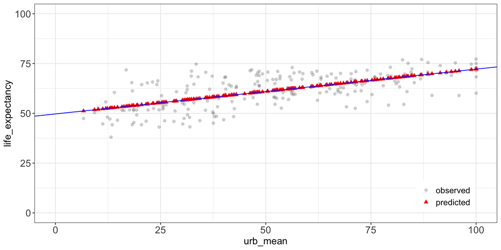

## Regression Line

### Regression Example

Actual (circles) - predicted value (triangles) = **residual**.

$$\text{residual}_i = y_i - \hat{y}_i$$

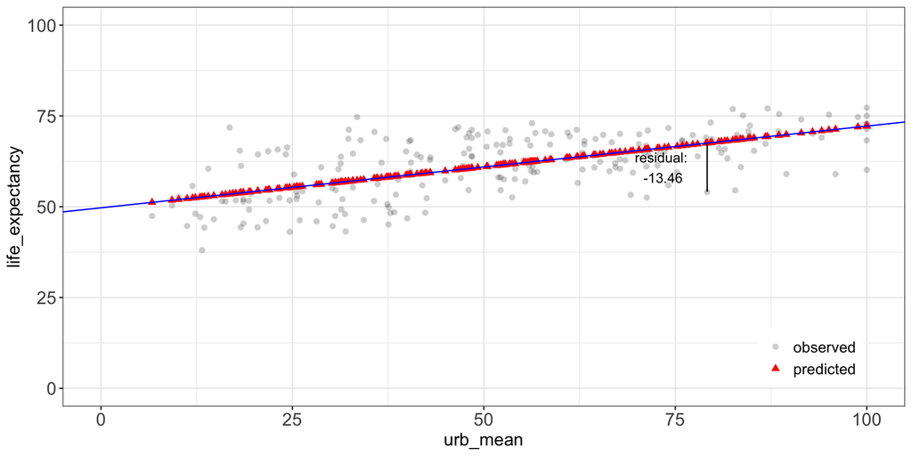

## Regression Example

We note that there is a difference between $y_i$ and $\hat{y_i}$, where:

$y_i$ is the country’s *observed value* on life expectancy

$\hat{y_i}$ is the country’s *predicted value* on life expectancy

We can obtain each country’s $\hat{y_i}$ by plugging their x-value into the regression equation.

The regression line is the straight line that minimizes the size of the residuals and makes them as small as possible.

This is why the regression line is sometimes called the *line of best fit*.

## Regression Example

### Interpretation

```r
x<-lm(life_expectancy~urb_mean, data=merged_data2)
summary(x)
```

```
Call:
lm(formula = life_expectancy ~ urb_mean, data = merged_data2)

Residuals:
     Min       1Q   Median       3Q      Max
-14.6442  -4.2065  -0.5017   5.0702  18.3283

Coefficients:
            Estimate Std. Error t value Pr(>|t|)
(Intercept) 49.69757    1.08225   45.92   <2e-16 ***
urb_mean     0.22529    0.01906   11.82   <2e-16 ***
---
Signif. codes:  0 '***' 0.001 '**' 0.01 '*' 0.05 '.' 0.1 ' ' 1

Residual standard error: 6.742 on 212 degrees of freedom
Multiple R-squared:  0.3971,    Adjusted R-squared:  0.3943
F-statistic: 139.7 on 1 and 212 DF,  p-value: < 2.2e-16
```

## Regression Example

### Interpretation

This is how we create a professionally-looking table.

```r
library("modelsummary")
model<-lm(life_expectancy~urb_mean, data=merged_data2)

models<-list("DV: Life Expectancy" = model)

cm <- c('urb_mean'='Urbanization',
        "(Intercept)"="Intercept")

modelsummary(models, stars = TRUE, coef_map = cm, gof_map = c("nobs", "r.squared"))
```

|  | DV: Life Expectancy |
| --- | --- |
| Urbanization | 0.225*** |
|  | (0.019) |
| Intercept | 49.698*** |
|  | (1.082) |
| Num.Obs. | 214 |
| R2 | 0.397 |

+ p < 0.1, * p < 0.05, ** p < 0.01, *** p < 0.001

## Regression Example

### Interpretation

This is how we create a professionally-looking plot.

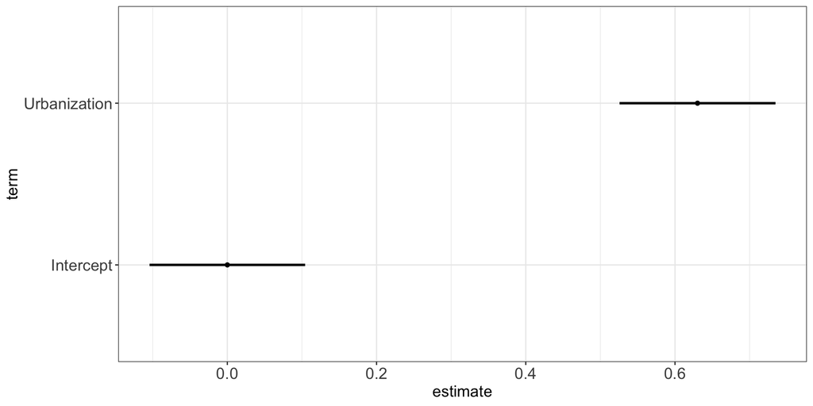

```r
library(broom)
model_scaled<-lm(scale(life_expectancy)~scale(urb_mean), data=merged_data2)
results<-tidy(model_scaled)

cm <- c('scale(urb_mean)'='Urbanization',
        "(Intercept)"="Intercept")

ggplot(results, aes(x = estimate, y = term)) +
      geom_point()+
      geom_errorbar(aes(xmin = estimate-1.96*std.error,
                        xmax = estimate+1.96*std.error),
                linewidth = 1, width=0)+
      scale_y_discrete(labels = cm) +  # this maps term names to nicer labels
      theme_bw()+
      theme(
        axis.text  = element_text(size = 14),
        axis.title = element_text(size = 14),
        plot.title = element_text(hjust = 0.5))
```

## Regression Example

### Interpretation: The Slope (b)

```r
library("modelsummary")
model<-lm(life_expectancy~urb_mean, data=merged_data2)

models<-list("DV: Life Expectancy" = model)

cm <- c('urb_mean'='Urbanization',
        "(Intercept)"="Intercept")

modelsummary(models, stars = TRUE, coef_map = cm, gof_map = c("nobs", "r.squared"))
```

|  | DV: Life Expectancy |
| --- | --- |
| Urbanization | 0.225*** |
|  | (0.019) |
| Intercept | 49.698*** |
|  | (1.082) |
| Num.Obs. | 214 |
| R2 | 0.397 |

+ p < 0.1, * p < 0.05, ** p < 0.01, *** p < 0.001

**Interpretation**:

For every 1 percentage point increase in urbanization (urb_mean), the model predicts an average increase of approximately 0.225 in life expectancy.

This relationship is statistically significant at the 0.1% level (p < 0.001), as indicated by the *** in the regression output.

## Regression Example

### Interpretation: The Standard Error (SE)

```r
library("modelsummary")
model<-lm(life_expectancy~urb_mean, data=merged_data2)

models<-list("DV: Life Expectancy" = model)

cm <- c('urb_mean'='Urbanization',
        "(Intercept)"="Intercept")

modelsummary(models, stars = TRUE, coef_map = cm, gof_map = c("nobs", "r.squared"))
```

|  | DV: Life Expectancy |
| --- | --- |
| Urbanization | 0.225*** |
|  | (0.019) |
| Intercept | 49.698*** |
|  | (1.082) |
| Num.Obs. | 214 |
| R2 | 0.397 |

+ p < 0.1, * p < 0.05, ** p < 0.01, *** p < 0.001

**Interpretation**:

SE for Urbanization = 0.019.

This tells you how much the estimate would vary across different samples. The smaller it is, the more precise your estimate.

## Regression Example

### Interpretation: The Intercept (a)

```r
library("modelsummary")
model<-lm(life_expectancy~urb_mean, data=merged_data2)

models<-list("DV: Life Expectancy" = model)

cm <- c('urb_mean'='Urbanization',
        "(Intercept)"="Intercept")

modelsummary(models, stars = TRUE, coef_map = cm, gof_map = c("nobs", "r.squared"))
```

|  | DV: Life Expectancy |
| --- | --- |
| Urbanization | 0.225*** |
|  | (0.019) |
| Intercept | 49.698*** |
|  | (1.082) |
| Num.Obs. | 214 |
| R2 | 0.397 |

+ p < 0.1, * p < 0.05, ** p < 0.01, *** p < 0.001

**Interpretation**:

Intercept = 49.698 When urbanization is 0%, the predicted life expectancy is 49.698 years.

This is not always meaningful in practice (e.g., no country has exactly 0% urbanization), but it’s mathematically necessary.

## Regression Example

### Interpretation: R Squared

The $R^2$ is 0.397

It tells us the variance explained in our outcome variable by our predictor variable(s).

The interpretation is: “Our model explains 39.7% of the variance in our outcome variable.”

R squared ranges from 0 to 1: $R\in [0,1]$

- R sq = 0 means no variance is explained
- R sq = 1 means that all variance is explained

## Notation

We now have the following equation:

$$\hat{Y} = bX + a$$

This can also be written as:

$$\hat{y} = \hat{\alpha} + \hat{\beta}_1 x + \epsilon$$

$$\hat{y} = \hat{\beta}_0 + \hat{\beta}_1 x + \epsilon$$

Where:

$a = \alpha = \beta_0$

$b = \beta_1$

$\epsilon$ = error term

## Conclusion

- **Correlation** quantifies the strength and direction of a linear relationship between two variables.
- **Regression** models this relationship to make predictions.
- The **slope ($\beta_1$)** tells us the expected change in the outcome for a one-unit change in the predictor.
- The **intercept ($\beta_0$)** gives the expected value when the predictor is zero.
- **$R^2$** measures how well the model explains variation in the outcome.
- **Correlation and regression do *not* imply causation.**